# 되돌아보기

## 웹 크롤러

우리가 BeautifulSoup, Selenium 등을 사용해서 한 작업과 뭔가 조금 느낌이 다른 것 같은데?

- 웹 크롤러: 조직적,자동화된 방법으로 월드 와이드 웹을 탐색하는 컴퓨터 프로그램
- 웹 크롤링: 웹 크롤러가 하는 작업
- 파싱: 구문 분석
- 웹 스크래핑: 웹 사이트상에서 원하는 데이터를 추출하는 것 즉, 우리가 했던 작업은 `웹 스크래핑`이 더 정확한 표현!

  관용적으로 `웹 크롤링`이라 하는 것

# Request, BeautifulSoup, Selenium

- Requests: Python HTTP 라이브러리 (HTTP 요청을 주고 받을 수 있는 파이썬 라이브러리)
- BeautifulSoup: HTML 문서를 파싱하는 라이브러리
- Selenium: 웹 브라우저 자동화를 위한 도구 모음(스크래핑에 유용하게 사용할 수 있음)

# Requests 사용법

```python
import requests

#requests를 이용해 원하는 웹페이지의 소스코드를 불러옴
res = requests.get("https://~")

#BeautifulSoup를 이용해 파싱
soup = bs(res.content, 'html.parser')
print(soup)
```

## BeautifulSoup사용법

```python
import requests
from bs4 import BeautifulSoup as bs

#requests를 이용해 원하는 웹페이지의 소스코드를 불러옴
res = requests.get("~")

#BeautifulSoup를 이용해 파싱
soup = bs(res.content, 'html.parser')
print(soup)
```

### HTML을 잘 분석해보자

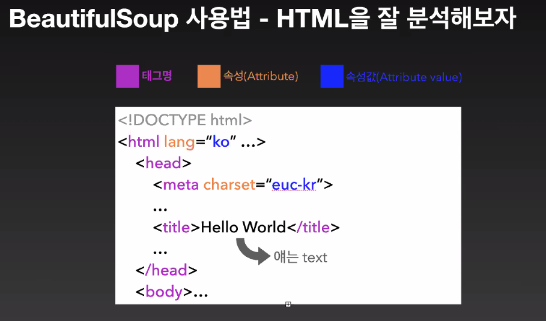

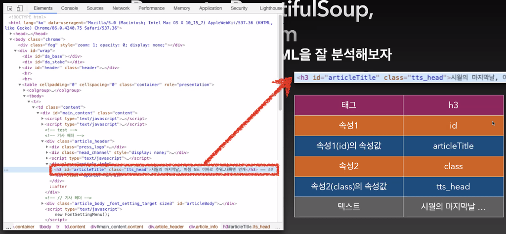

Tip

- id는 단 하나의 요소에만 스타일을 지정하고 싶을 때 사용(CSS Selector로써 접근할 때 => #속성값)
- class는 요소들을 그룹으로 묶어서 스타일을 지정할 때 쓰임(CSS Selector로써 접근할 때 => .속성값)

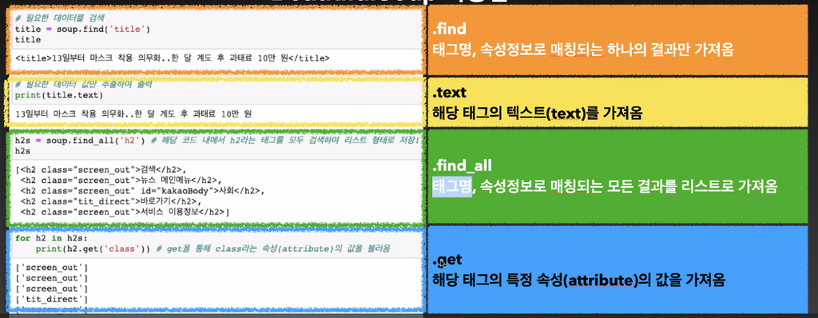

`.select()` : CSS Selector를 통해 매칭되는 모든 결과를 리스트로 가져옴

### 띄어쓰기 주의! 띄어쓰기에 따라 class가 한 개일수도, 두 개일수도 있다!

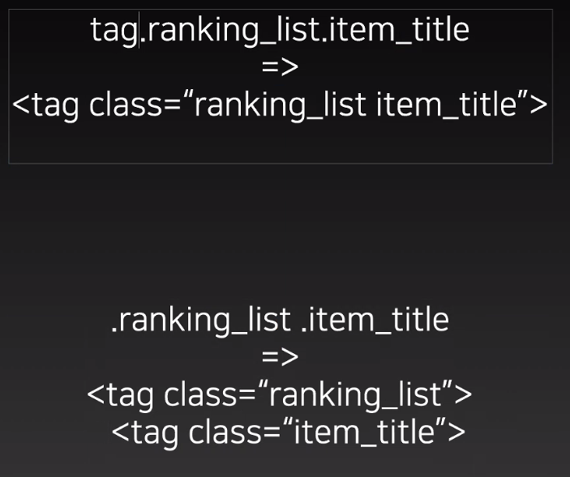

## Selenium 사용법

```python
#아나콘다에 포함된 라이브러리가 아니므로 새로 설치!
pip install selenium

from selenium import webdriver
from bs4 import BeautifulSoup
driver = webdriver.Chrome('./chromedriver')

#페이지가 다 로드될 때까지 3초 기다려주는 코드
driver.implicitly_wait(3)

#셀레니움을 통해 실제 크롬창을 열어 해당 URL 내용을 가져옴
driver.get('https://news.google.com~')

#소스를 읽어 BeautifulSoup를 이용해 파싱
html = driver.page_source
soup = BeautifulSoup(html, 'html.parser')

##Selenium에게 특정 동작을 시키기 위해 영역을 지정하는 방법(BeautifulSoup과는 조금 다르다)
#스크롤을 하기위한 영역 찾기
scroll_area = driver.find_element_by_xpath('//*[@id=~'']')

#해당 영역까지 일단 전체 화면을 스크롤
action = webdriver.ActionChains(driver)
action.move_to_element(scroll_area).perform()

#해당 영역 내부를 제일 하단까지 스크롤
driver.execute_script("arguments[0].scrollTop = arguments[0].scrollHeight", scroll_area)

#화면에 값들이 변경되었으므로 다시 BeautifulSoup를 이용해 파싱
html = driver.page_source
soup = BeautifulSoup(html, 'html.parser')

## 요 영역은 다시 BeautifulSoup이용!
#우리가 필요한 정보 부분을 선택(.은 class, #은 id)
covid_list = soup.select("tr.sgXwHf.wdLSAe")

#불러온 리스트의 개수 다시 확인
print("covid_list length: ", len(covid_list))
print("-"*100)

#전체 리스트 출력
printInfoAll(covid_list)
```

# 엄밀히 말하면 웹스크래핑!

```
웹크롤링을 해보자!
1. JSON, API?
2. 네이버 오픈 API를 이용한 크롤링(스크래핑)
3. 다시 한번 실습 및 정리
```

- JSON이란: 파이썬의 dictionary와 매우 비슷하지만, JSON은 통신 등을 통해 데이터를 주고 받기 위한 것이기 때문에 언어에 국한되지 않은 문자열 형태이다.

## JSON 사용법

- 통신을 통해 데이터를 주고 받기 때문에 문자열 형태로 전달된다. 이것을 우리는 dictionary형태로 변환해서 사용하면 된다!

```python
json_str = '{"name":"jack", "age":20}'
json_str
```

```
'{"name":"jack", "age":20}'
```

```python
import json
result = json.loads(json_str)
print(result)
print(type(result))
print(result['name'])
```

```
{'name': 'jack', 'age': 20}
<class 'dict'>
jack
```

## API란?

응용 프로그램에서 사용할 수 있도록, 운영 체제나 프로그래밍 언어가 제공하는 기능을 제어할 수 있게 만든 인터페이스.

Open API는 누구나 사용할 수 있도록 공개된 API를 말한다.

네이버 오픈 API를 예로들면, 네이버가 제공하는 특정 기능들을 API를 사용하여 나만의 프로그램을 만들 수 있는 것이다.(ex.블로그 포스팅, 검색 결과 조회 등)

보통 이러한 API를 사용하면 그 결과값이 JSON 형태로 주어진다. 즉, 우리는 이 JSON 형태의 값을 받아서 파싱하여 우리의 파이썬 코드내에서 사용하면 된다!

```python
import requests
#네이버 오픈 API를 사용하기 위한 어플리케이션 KEY / Secret
client_key = "JMIvub7nT8wZlPQyqXzy"
client_secret = "d3HDutfZBH"

url="https://openapi.naver.com/v1/search/news.json?query=아이폰12"
# search = input("검색어를 입력하세요.")
# url = "https://openapi.naver.com/v1/search/news.json?query="+str(search)
header_params = {"X-Naver-Client-Id":client_key, "X-Naver-Client-Secret":client_secret}
response = requests.get(url, headers = header_params)


#결과값 출력
print(response.text)
```

```
{
"lastBuildDate": "Sat, 31 Oct 2020 15:59:27 +0900",
"total": 96343,
"start": 1,
"display": 10,
"items": [
{
"title": "&quot;배터리 녹는다…&quot; <b>아이폰12</b> 시리즈, 역대급 혹평 쏟아졌다",
"originallink": "https://www.wikitree.co.kr/articles/586600",
"link": "https://www.wikitree.co.kr/articles/586600",
"description": "애플이 <b>아이폰12</b>와 <b>아이폰12</b> 프로 판매를 시작한 가운데 배터리 성능이 혹평을 들었다.  30일 IT전문 매체 폰아레나는 <b>아이폰12</b> 프로 시리즈에 대한 웹브라우징, 동영상 재생, 3D 게이밍 배터리... ",
"pubDate": "Sat, 31 Oct 2020 15:03:00 +0900"

},
{
"title": "<b>아이폰12</b> 시리즈 국내 상륙, 프로모션 혜택 강화",
"originallink": "http://www.lawissue.co.kr/view.php?ud=202010301618577198992c130dbe_12",
"link": "http://www.lawissue.co.kr/view.php?ud=202010301618577198992c130dbe_12",
"description": "지난 30일 국내 시장에서 정식 출시를 시작한 <b>아이폰12</b>, <b>아이폰12</b> PRO 중 프로 모델을 선택한 소비자의 비중이 압도적인 것으로 알려졌다. 업계 관계자는 “신종 코로나 바이러스의 여파로 인해 고가 플래그십 모델에... ",
"pubDate": "Sat, 31 Oct 2020 15:01:00 +0900"

},
{
"title": "핫버스폰, <b>아이폰12</b> 출시 인기 올라, 갤럭시노트20 이어, Z플립 10만원대 프로...",
"originallink": "http://www.ujeil.com/news/articleView.html?idxno=264285",
"link": "http://www.ujeil.com/news/articleView.html?idxno=264285",
"description": "사진제공=핫버스폰 애플의 <b>아이폰12</b> MINI와 <b>아이폰12</b> PRO MAX가 내달 20일 출시를 진행할 것으로 전망된다. 지난 29일 이동통신 업계에 따르면 해당 두 모델은 11월 13일부터 사전 예약을 시작하고, 20일 출시될 예정인... ",
"pubDate": "Sat, 31 Oct 2020 15:00:00 +0900"

},
{
"title": "'전국5G맛집' 갤럭시Z 플립 출고가 인하 10만원대 좌표 공개 더불어 갤럭시S2...",
"originallink": "http://www.hkrecruit.co.kr/news/articleView.html?idxno=22610",
"link": "http://www.hkrecruit.co.kr/news/articleView.html?idxno=22610",
"description": "사진제공=전국5G맛집 애플의 <b>아이폰12</b> 시리즈가 높은 사전예약 신청자 수를 기록하고 있는 한편 삼성전자의 두번째 폴더블 스마트폰 갤럭시Z 플립 모델의 출고가가 한번 더 인하돼 화제가 되고 있다. 이는 애플의... ",
"pubDate": "Sat, 31 Oct 2020 14:01:00 +0900"

},
{
"title": "[글로벌-Biz24] ‘佛에는 있는데 우린 왜 없어’…‘<b>아이폰12</b>’ 겨냥 러시아 ...",
```

[output cut: 33 more lines]

```
"link": "http://www.sisajournal-e.com/news/articleView.html?idxno=225185",
"description": "이는 올해 <b>아이폰12</b> 시리즈 출시 일정이 예년과 달리 3분기에서 4분기로 밀린 영향이다. 그러나 올 4분기 들어 이 같은 시장 순위는 재편될 것으로 예상된다. 애플이 이달 5G를 지원하는 <b>아이폰 12</b> 시리즈를... ",
"pubDate": "Sat, 31 Oct 2020 10:03:00 +0900"

},
{
"title": "'스마트콕콕' <b>아이폰12</b> 정식 출시, 아이폰SE2, XR 가격 공짜폰 좌표 공개",
"originallink": "http://www.newsrep.co.kr/news/articleView.html?idxno=152315",
"link": "http://www.newsrep.co.kr/news/articleView.html?idxno=152315",
"description": "애플의 첫 5G 스마트폰 <b>아이폰12</b>와 <b>아이폰12</b>프로가 10월 30일 정식 출시되었다. 전작 대비 사전 예약 분위기가 좋은 것으로 알려진 가운데 11월 20일 출시 예정인 <b>아이폰12</b>미니, <b>아이폰12</b>프로맥스에  대한 관심도... ",
"pubDate": "Sat, 31 Oct 2020 10:00:00 +0900"

}
]
}
```

```python
import json
#HTTP 응답 코드는 stats_code에 저장되며, 200은 요청이 정상적으로 처리되었음을 의미
if(response.status_code==200):
## API를 통해 불러온 데이터를 내 마음대로 사용
    #json 모듈을 사용한 방법
    #results = json.loads(response.text)

    #requests 라이브러리가 제공하는 json 메서드 사용
    result = response.json()
    for item in result['items']:
        print("Title: ", item['title'])
        print("Desc: ", item['description'])

else:
    print("[Error] Status code: ", response.status_code)
```

```
Title:  &quot;배터리 녹는다…&quot; <b>아이폰12</b> 시리즈, 역대급 혹평 쏟아졌다
Desc:  애플이 <b>아이폰12</b>와 <b>아이폰12</b> 프로 판매를 시작한 가운데 배터리 성능이 혹평을 들었다.  30일 IT전문 매체 폰아레나는 <b>아이폰12</b> 프로 시리즈에 대한 웹브라우징, 동영상 재생, 3D 게이밍 배터리...
Title:  <b>아이폰12</b> 시리즈 국내 상륙, 프로모션 혜택 강화
Desc:  지난 30일 국내 시장에서 정식 출시를 시작한 <b>아이폰12</b>, <b>아이폰12</b> PRO 중 프로 모델을 선택한 소비자의 비중이 압도적인 것으로 알려졌다. 업계 관계자는 “신종 코로나 바이러스의 여파로 인해 고가 플래그십 모델에...
Title:  핫버스폰, <b>아이폰12</b> 출시 인기 올라, 갤럭시노트20 이어, Z플립 10만원대 프로...
Desc:  사진제공=핫버스폰 애플의 <b>아이폰12</b> MINI와 <b>아이폰12</b> PRO MAX가 내달 20일 출시를 진행할 것으로 전망된다. 지난 29일 이동통신 업계에 따르면 해당 두 모델은 11월 13일부터 사전 예약을 시작하고, 20일 출시될 예정인...
Title:  '전국5G맛집' 갤럭시Z 플립 출고가 인하 10만원대 좌표 공개 더불어 갤럭시S2...
Desc:  사진제공=전국5G맛집 애플의 <b>아이폰12</b> 시리즈가 높은 사전예약 신청자 수를 기록하고 있는 한편 삼성전자의 두번째 폴더블 스마트폰 갤럭시Z 플립 모델의 출고가가 한번 더 인하돼 화제가 되고 있다. 이는 애플의...
Title:  [글로벌-Biz24] ‘佛에는 있는데 우린 왜 없어’…‘<b>아이폰12</b>’ 겨냥 러시아 ...
Desc:  애플이 ‘환경보호’를 명분으로 ‘<b>아이폰12</b>’에 충전 어댑터와 이어폰을 구성품에서 제외한 데 대해 러시아에서 소송 움직임이 일고 있다. 29일(현지시간) 러시아 매체인 씨뉴스(cnews)은 애플이 새로운 아이폰에...
Title:  모모폰, 갤럭시 및 <b>아이폰</b> 초등학생 무료 키즈폰 프로모션 진행
Desc:  얼마 전에는 애플의 첫 5G 모델인 <b>아이폰12</b> 시리즈가 출시되어 큰 인기를 끌고 있는 양상이다. 플래그십 모델들이 다양하게 출시되고 있지만 출고가가 높아 학부모들은 아이들에게 플래그십 모델 보다는 가격이 낮아진...
Title:  [주간 테크 뉴스] &quot;코로나19 백신, 윤곽 나왔다&quot;… 승기 잡을 제약사 '누구'
Desc:  애플·이통사 갑질에 휴대폰 판매점 이중고 애플의 <b>아이폰12</b> 시리즈 출시를 앞두고 단말 유통 업계의 시름이 깊다. 애플의 아이폰을 판매하는 유통업체는 의무적으로 시연용 아이폰을 직접 구입해야 해 기기값에...
Title:  사나폰, '<b>아이폰12</b> 미니 및 프로 맥스' 사전예약 할인 혜택 제공 및 에어팟 프...
Desc:  사나폰은 유튜버 '찬웅팀장'이 운영하는 커뮤니티 사이트로, <b>아이폰12</b> 시리즈의 사전예약 구매자에게 '에어팟 프로'와 '프로모션혜택' 등을 내세워 구매를 원하는 소비자들이 이목을 끌고 있다. 앞서, 애플의 신작...
Title:  삼성폰, 3분기 中 화웨이 제치고 1위···4분기는 '미지수'
Desc:  이는 올해 <b>아이폰12</b> 시리즈 출시 일정이 예년과 달리 3분기에서 4분기로 밀린 영향이다. 그러나 올 4분기 들어 이 같은 시장 순위는 재편될 것으로 예상된다. 애플이 이달 5G를 지원하는 <b>아이폰 12</b> 시리즈를...
Title:  '스마트콕콕' <b>아이폰12</b> 정식 출시, 아이폰SE2, XR 가격 공짜폰 좌표 공개
Desc:  애플의 첫 5G 스마트폰 <b>아이폰12</b>와 <b>아이폰12</b>프로가 10월 30일 정식 출시되었다. 전작 대비 사전 예약 분위기가 좋은 것으로 알려진 가운데 11월 20일 출시 예정인 <b>아이폰12</b>미니, <b>아이폰12</b>프로맥스에  대한 관심도...
```

# 알고리즘

```
1. 알고리즘이란?
2. 계산 복잡도
3. 직접 만들어보기
```

알고리즘이란 간단히 말하면 '어떤 문제를 풀기 위한 절차나 방법'

### '절대값 구하기'로 알아보는 알고리즘

- 문제: 어떤 숫자의 절대값구하기
- 입력: 절대값을 구할 실수 a
- 출력: a의 절대값

#### 부호 판단

1. 만약 a가 0보다 크거나 같다면 a를 그대로 결과값으로 돌려줌
2. 1의 경우가 아니라면(a가 0보다 작으면) -a를 결과로 돌려줌

#### 제곱 후 제곱근

1. a를 제곱하여 변수 b에 할당
2. b의 제곱근을 구해 결과로 돌려줌

```python
import math #math 모듈 사용
def get_abs_by_square(a):
    b = a * a
    return math.sqrt(b) #제곱근을 구하는 함수
```

```python
def get_abs(a):
    b = (a**2)**(1/2)
    return b
```

```python
def jeoldaegab(x):
    a = x**2
    b = a**0.5
    print(b)
    return b
```

```python
def 제곱근(a):
    b = a**2
    return b ** 0.5
```

```python
def abs_try(a):
    b = np.square(a)
    print(np.sqrt(b))
```

```python
def get_abs3(a):
    b = a**2
    return b**0.5
```

## 알고리즘 기초

### '1부터 n까지의 합 구하기'로 알아보는 알고리즘

#### 하나씩 더해가는 방법

1. 합을 기록할 변수 s을 만들고 0을 할당
2. 변수 i를 만들어 1부터 n까지 숫자를 1씩 증가시키며 반복
3. 반복하면서, 기존의 s에 i를 더하여 얻은 값을 다시 s에 할당
4. 반복이 끝나면 s에 저장된 값을 돌려줌

```python
def sum_n(n):
    s = 0
    for i in range(1, n+1):
        s += i
    return s
```

#### 일반화된 수식을 이용하는 방법

1. 등차수열 합공식 이용!(이 경우엔 첫째항이 1, 공차 1, 끝항 100)

```python
def sum_n(n):
    return n * (n + 1) // 2 # //는 정수 나눗셈(쯕 몫만 가져옴!)
```

```python
print(sum_n(2))
```

```
3
```

#### 파이썬 내장함수를 이용하는 방법

```python
list_n_to_100 = list(range(1, 101))
print(list_n_to_100)
print(sum(list_n_to_100))
```

```
[1, 2, 3, 4, 5, 6, 7, 8, 9, 10, 11, 12, 13, 14, 15, 16, 17, 18, 19, 20, 21, 22, 23, 24, 25, 26, 27, 28, 29, 30, 31, 32, 33, 34, 35, 36, 37, 38, 39, 40, 41, 42, 43, 44, 45, 46, 47, 48, 49, 50, 51, 52, 53, 54, 55, 56, 57, 58, 59, 60, 61, 62, 63, 64, 65, 66, 67, 68, 69, 70, 71, 72, 73, 74, 75, 76, 77, …
5050
```

### 계산복잡도

- 알고리즘이 문제를 풀기 위해 해야 하는 계산이 얼마나 복잡한지 나타내는 정도를 '계산복잡도'라고 한다.

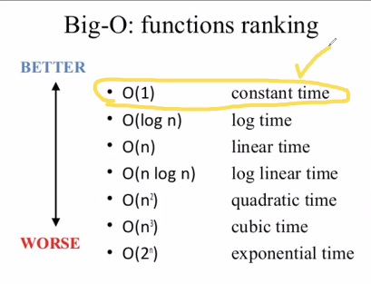

1부터 n까지 제곱의 합을 구하는 알고리즘은?

```python
def squared_sum_n(n):
    return n * (n+1) * (2*n + 1) // 6
```

```python
print(squared_sum_n(3))
```

```
14
```

```python
def squared_sum_n(n):
    s = 0
    for i in range(1, n+1):
        s += i**2
    return s
```

```python
print(squared_sum_n(3))
```

```
14
```